# Homework 3

Dylan Maddux

2024-09-30

```r
library(Stat2Data)
library(ggplot2)
library(dplyr)
```

### Exercise 3.16

**A dean at a small liberal arts college is interested in fitting a multiple regression model to try to predict salaries for faculty members. If the residuals are unusually large for any individual faculty member, then adjustments in the person’s annual salary are considered.**

**A.** Identify the model for predicting Salary from age of the faculty member (Age), years of experience (Seniority), number of publications (Pub), and an indicator variable for gender (IGender). The dean wants this initial model to include only pairwise interaction terms.

Salary = $\beta0$ + $\beta1Age$ + $\beta2Seniority$ + $\beta3Pub$ + $\beta4IGender$

**B.** Do you think that Age and Seniority will be correlated? Explain.

Yes, I think that Age and Seniority will be correlated because the older the faculty members are, the more likely they are to have been a professor for a longer period of time.

**C.** Do you think that Seniority and Pub will be correlated? Explain.

Yes, I think that Seniority and Pub will be correlated because the more experience faculty members have, the more likely they are to have been publishing articles for a longer period of time and thus will have more publications.

**D.** Do you think that the dean will be happy if the coefficient for IGender is significantly different from zero? Explain.

No, I don’t think that the dean would be happy since this would indicate that salaries for male and female professors with the same age, experience, and publications are significantly different.

### Exercise 3.18

**Consider the RailsTrails data, which gives information about 104 homes sold in Northampton, Massachusetts, in 2007. In this exercise, use Adj2007 (the 2007 selling price in adjusted 2014 thousands of dollars) as the response variable and Distance (distance from a bike trail) and SquareFeet (size of home, in 1000s) as two explanatory variables. The primary interest of the researchers was to ascertain the selling price impact of being close to a bike trail.**

**A.** First fit the simple linear regression model of Adj2007 on Distance.

```r
data("RailsTrails")
rtmodel1 <- lm(Adj2007~Distance, RailsTrails)
summary(rtmodel1)
```

```
##
## Call:
## lm(formula = Adj2007 ~ Distance, data = RailsTrails)
##
## Residuals:
##     Min      1Q  Median      3Q     Max
## -190.55  -58.19  -17.48   25.22  444.41
##
## Coefficients:
##             Estimate Std. Error t value Pr(>|t|)
## (Intercept)  388.204     14.052  27.626  < 2e-16 ***
## Distance     -54.427      9.659  -5.635 1.56e-07 ***
## ---
## Signif. codes:  0 '***' 0.001 '**' 0.01 '*' 0.05 '.' 0.1 ' ' 1
##
## Residual standard error: 92.13 on 102 degrees of freedom
## Multiple R-squared:  0.2374, Adjusted R-squared:  0.2299
## F-statistic: 31.75 on 1 and 102 DF,  p-value: 1.562e-07
```

**B.** Next, fit a regression model with both explanatory variables. Has the addition of SquareFeet changed our estimate of the Distance relationship to Adj2007? Use both the estimated coefficient and R^2 in your answer.

```r
rtmodel2 <- lm(Adj2007~Distance + SquareFeet, RailsTrails)
summary(rtmodel2)
```

```
##
## Call:
## lm(formula = Adj2007 ~ Distance + SquareFeet, data = RailsTrails)
##
## Residuals:
##      Min       1Q   Median       3Q      Max
## -138.835  -32.621   -1.903   27.369  145.504
##
## Coefficients:
##             Estimate Std. Error t value Pr(>|t|)
## (Intercept)  109.742     20.057   5.472 3.25e-07 ***
## Distance     -16.486      5.942  -2.775  0.00659 **
## SquareFeet   150.780      9.998  15.080  < 2e-16 ***
## ---
## Signif. codes:  0 '***' 0.001 '**' 0.01 '*' 0.05 '.' 0.1 ' ' 1
##
## Residual standard error: 51.34 on 101 degrees of freedom
## Multiple R-squared:  0.7655, Adjusted R-squared:  0.7608
## F-statistic: 164.8 on 2 and 101 DF,  p-value: < 2.2e-16
```

Yes, the addition of SquareFeet changed our estimate of the Distance relationship to Adj2007, as the estimated coefficient for Distance decreased from -54.43 to -16.49 and the R^2 of the model increased from 23.74% to 76.55%, strengthening the model significantly.

**C.** Find 95% confidence intervals for the distance coefficient from each model and compare them.

```r
confint(rtmodel1)
```

```
##                2.5 %    97.5 %
## (Intercept) 360.3317 416.07588
## Distance    -73.5859 -35.26851
```

```r
confint(rtmodel2)
```

```
##                 2.5 %     97.5 %
## (Intercept)  69.95460 149.530197
## Distance    -28.27307  -4.698861
## SquareFeet  130.94601 170.614247
```

In the first model, the confidence interval for distance coefficient is (-73.59, -35.27), while in the second model it is (-28.27,-4.70). The range is not only narrower in the second model which implies that it would provide a better prediction, but also includes much smaller values.

**D.** Using the two-predictor model, give a prediction for the price of a particular home that goes on the market and that has 1500 square feet of space and is 0.5 mile from a bike trail.

```r
rtmodel2
```

```
##
## Call:
## lm(formula = Adj2007 ~ Distance + SquareFeet, data = RailsTrails)
##
## Coefficients:
## (Intercept)     Distance   SquareFeet
##      109.74       -16.49       150.78
```

```r
109.74-(16.49*0.5)+(150.78*1500)
```

```
## [1] 226271.5
```

### Exercise 3.26

**The file Tadpoles includes the variable Treatment, which has two levels: “Bd” for 14 exposed tadpoles and “Control” for 13 control tadpoles. The variable GutLength is the length (in mm) of the intestinal tract. The variable Body is the length (in mm) of the body of the tadpole, and the variable MouthpartDamage is a measure of damage to the mouth (missing teeth, etc.).**

**A** Make a scatterplot of “Y = GutLength” versus “X = Body” and with Treatment as a grouping variable. Comment on the plot.

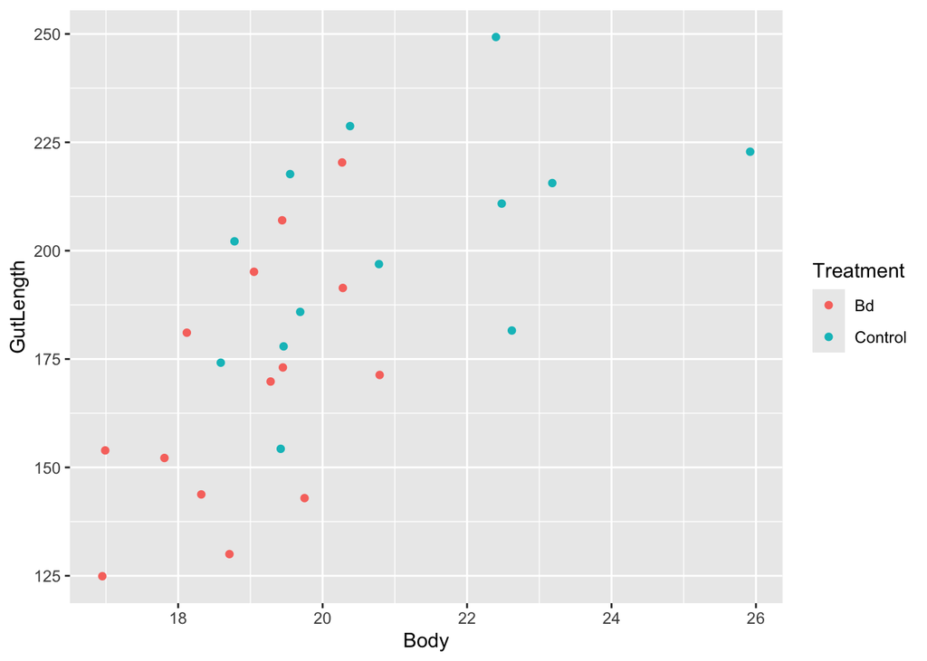

```r
data("Tadpoles")
ggplot(Tadpoles, aes(Body, GutLength, color = Treatment)) +
  geom_point()
```

The plot displays a linear positive relationship between Body and Gut Length, while tadpoles in the control group had larger bodies and longer Gut Lengths than tadpoles in the treatment group.

**B.** Fit the regression of GutLength on Body and test whether there is a linear association between the two variables.

```r
tpmodel1 <- lm(GutLength~Body, Tadpoles)
summary(tpmodel1)
```

```
##
## Call:
## lm(formula = GutLength ~ Body, data = Tadpoles)
##
## Residuals:
##     Min      1Q  Median      3Q     Max
## -41.575 -22.245   0.027  17.815  39.998
##
## Coefficients:
##             Estimate Std. Error t value Pr(>|t|)
## (Intercept)  -20.764     49.002  -0.424 0.675384
## Body          10.280      2.445   4.204 0.000293 ***
## ---
## Signif. codes:  0 '***' 0.001 '**' 0.01 '*' 0.05 '.' 0.1 ' ' 1
##
## Residual standard error: 24.83 on 25 degrees of freedom
## Multiple R-squared:  0.4141, Adjusted R-squared:  0.3907
## F-statistic: 17.67 on 1 and 25 DF,  p-value: 0.0002931
```

```r
cor(Tadpoles$GutLength, Tadpoles$Body)
```

```
## [1] 0.6435303
```

The linear model summary provides a statistically significant p-value of the effect of Body on Gut Length. Furthermore, the R^2 value is 41.41% and the correlation coefficient is 0.64, suggesting a moderately strong linear association between the two variables.

**C.** Fit a model that produces parallel regression lines for the two levels of Treatment. Write down the fitted prediction equation for each level of Treatment.

```r
tpmodel2 <- lm(GutLength~Body+Treatment, Tadpoles)
summary(tpmodel2)
```

```
##
## Call:
## lm(formula = GutLength ~ Body + Treatment, data = Tadpoles)
##
## Residuals:
##     Min      1Q  Median      3Q     Max
## -36.462 -15.006  -2.545  19.117  41.298
##
## Coefficients:
##                  Estimate Std. Error t value Pr(>|t|)
## (Intercept)         15.47      53.81   0.288  0.77618
## Body                 8.07       2.82   2.862  0.00859 **
## TreatmentControl    16.28      11.03   1.476  0.15286
## ---
## Signif. codes:  0 '***' 0.001 '**' 0.01 '*' 0.05 '.' 0.1 ' ' 1
##
## Residual standard error: 24.26 on 24 degrees of freedom
## Multiple R-squared:  0.4629, Adjusted R-squared:  0.4181
## F-statistic: 10.34 on 2 and 24 DF,  p-value: 0.0005762
```

$\hat{TreatmentGutLength}$ = 8.07*Body + 15.47

$\hat{ControlGutLength}$ = 8.07*Body + 31.75

**D.** Expand the model from part (c) by adding MouthpartDamage as a predictor. How does this fitted model relate to the question that the biologists had?

```r
tpmodel3 <- lm(GutLength~Body+Treatment+MouthpartDamage, Tadpoles)
summary(tpmodel3)
```

```
##
## Call:
## lm(formula = GutLength ~ Body + Treatment + MouthpartDamage,
##     data = Tadpoles)
##
## Residuals:
##     Min      1Q  Median      3Q     Max
## -39.422 -17.701  -6.771  16.338  40.877
##
## Coefficients:
##                  Estimate Std. Error t value Pr(>|t|)
## (Intercept)       -20.258     53.070  -0.382   0.7062
## Body                6.442      2.746   2.346   0.0280 *
## TreatmentControl   25.412     11.177   2.274   0.0326 *
## MouthpartDamage    96.839     45.839   2.113   0.0457 *
## ---
## Signif. codes:  0 '***' 0.001 '**' 0.01 '*' 0.05 '.' 0.1 ' ' 1
##
## Residual standard error: 22.68 on 23 degrees of freedom
## Multiple R-squared:  0.5502, Adjusted R-squared:  0.4915
## F-statistic: 9.378 on 3 and 23 DF,  p-value: 0.0003092
```

In this fitted model, greater Mouthpart Damage is associated with longer Gut Length, which falls in line with the biologist’s expectations. Their question was whether Gut Length will also have a positive association with Treatment, in which the answer is ‘Yes’ since the coefficient estimate in the linear model for Treatment on Gut Length is positive.

### Exercise 3.30

**Biologists measured oxygen consumption of shore crabs that were either exposed to 7.5 minutes of ship-noise or 7.5 minutes of ambient harbor noise. The file CrabShip includes the variable Noise, which has two levels: “ambient” and “ship.” The variable Mass (g) is the mass of the crab. The variable Oxygen ($\mu$molesh^-1) is the rate of oxygen consumption.**

**A.** Make a scatterplot of ‘Y = Oyxgen’ versus ‘X = Mass’ and with Noise as a grouping variable (i.e., use different colors or different plotting symbols for the two levels of Noise). Comment on the plot.

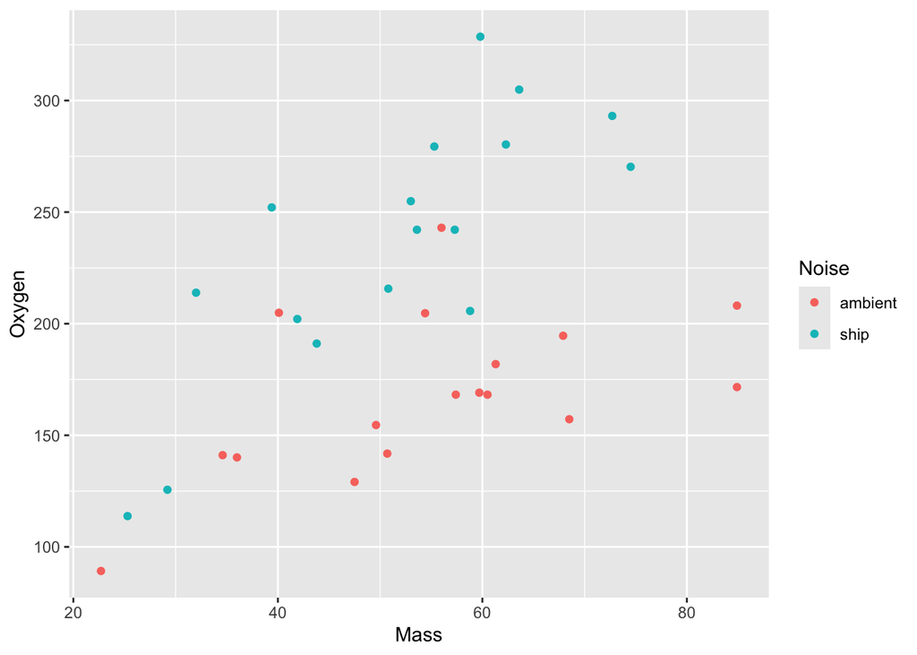

```r
data("CrabShip")
ggplot(CrabShip, aes(Mass, Oxygen, color = Noise)) +
  geom_point()
```

Mass and oxygen consumption seem to have a relatively linear positive relationship, with crabs in the ship noise condition exhibiting a steeper increase in the level of oxygen consumption as mass increases compared to crabs in the ambient noise condition.

**B.** Fit the regression of Oxygen on Mass and test whether there is a linear association between the two variables.

```r
csmodel1 <- lm(Oxygen~Mass, CrabShip)
summary(csmodel1)
```

```
##
## Call:
## lm(formula = Oxygen ~ Mass, data = CrabShip)
##
## Residuals:
##     Min      1Q  Median      3Q     Max
## -86.785 -41.557  -3.188  38.177 114.558
##
## Coefficients:
##             Estimate Std. Error t value Pr(>|t|)
## (Intercept) 108.3950    33.2650   3.259  0.00265 **
## Mass          1.7667     0.6011   2.939  0.00606 **
## ---
## Signif. codes:  0 '***' 0.001 '**' 0.01 '*' 0.05 '.' 0.1 ' ' 1
##
## Residual standard error: 53.02 on 32 degrees of freedom
## Multiple R-squared:  0.2126, Adjusted R-squared:  0.188
## F-statistic: 8.639 on 1 and 32 DF,  p-value: 0.006063
```

```r
cor(CrabShip$Oxygen, CrabShip$Mass)
```

```
## [1] 0.4610613
```

**C.** Fit a model that produces parallel regression lines for the two levels of Noise.

```r
csmodel2 <- lm(Oxygen~Mass+Noise, CrabShip)
summary(csmodel2)
```

```
##
## Call:
## lm(formula = Oxygen ~ Mass + Noise, data = CrabShip)
##
## Residuals:
##     Min      1Q  Median      3Q     Max
## -68.364 -18.938  -3.953  17.210  74.905
##
## Coefficients:
##             Estimate Std. Error t value Pr(>|t|)
## (Intercept)  54.4279    24.9816   2.179   0.0371 *
## Mass          2.0734     0.4231   4.901 2.85e-05 ***
## Noiseship    75.2795    12.8000   5.881 1.72e-06 ***
## ---
## Signif. codes:  0 '***' 0.001 '**' 0.01 '*' 0.05 '.' 0.1 ' ' 1
##
## Residual standard error: 37.03 on 31 degrees of freedom
## Multiple R-squared:  0.6278, Adjusted R-squared:  0.6038
## F-statistic: 26.15 on 2 and 31 DF,  p-value: 2.221e-07
```

$\hat{OxygenAmbient}$ = 2.0734*Mass + 54.4279

$\hat{OxygenShip}$ = 2.0734*Mass + 129.7074

**D.** Fit the general model that produces nonparallel regression lines for the two levels of Noise.

```r
csmodel3 <- lm(Oxygen~Mass+Noise+Mass:Noise, CrabShip)
summary(csmodel3)
```

```
##
## Call:
## lm(formula = Oxygen ~ Mass + Noise + Mass:Noise, data = CrabShip)
##
## Residuals:
##     Min      1Q  Median      3Q     Max
## -54.719 -21.350  -4.149  12.715  73.261
##
## Coefficients:
##                Estimate Std. Error t value Pr(>|t|)
## (Intercept)    103.2703    29.3894   3.514  0.00142 **
## Mass             1.1869     0.5121   2.318  0.02746 *
## Noiseship      -34.3904    43.0782  -0.798  0.43096
## Mass:Noiseship   2.0705     0.7826   2.646  0.01286 *
## ---
## Signif. codes:  0 '***' 0.001 '**' 0.01 '*' 0.05 '.' 0.1 ' ' 1
##
## Residual standard error: 33.9 on 30 degrees of freedom
## Multiple R-squared:  0.6982, Adjusted R-squared:  0.6681
## F-statistic: 23.14 on 3 and 30 DF,  p-value: 5.942e-08
```

$\hat{OxygenAmbient}$ = 1.1869*Mass + 103.2703

$\hat{OxygenShip}$ = 3.2574*Mass + 68.8799

**E.** Which model, from part (b), part (c), or part (d), is the best choice, and why? Write down the fitted prediction equation for each level of Noise for your chosen model.

The model from part (d) is the best choice because it has a higher R^2 value and it describes a similar pattern as seen in the scatterplot where the slope of the ‘Ship’ noise condition is larger than the slope of the ‘Ambient’ noise condition; this is shown through the interaction coefficient demonstrating an increase in the effect of Mass on Oxygen Consumption when the noise condition is ‘Ship’.

$\hat{OxygenAmbient}$ = 1.1869*Mass + 103.2703

$\hat{OxygenShip}$ = 3.2574*Mass + 68.8799

### Exercise 3.44

**Consider a simple linear model to predict the number of doctors (MDs) from the number of hospitals (Hospitals) in a metropolitan area. Either the number of hospitals (Hospitals) or number of beds in those hospitals (Beds) might be good predictors of the number of doctors in a city.**

**A.** Find the correlations between each pair of the three variables, SqrtMDs, Hospitals, Beds. Based on these correlations, which of the two predictors would be a more effective predictor of SqrtMDs in a simple linear model by itself?

```r
data("CountyHealth")
ctyhlth <- CountyHealth %>%
  mutate(SqrtMDs = sqrt(MDs))
cor(ctyhlth$SqrtMDs, ctyhlth$Hospitals)
```

```
## [1] 0.9231113
```

```r
cor(ctyhlth$SqrtMDs, ctyhlth$Beds)
```

```
## [1] 0.9492056
```

```r
cor(ctyhlth$Hospitals, ctyhlth$Beds)
```

```
## [1] 0.9094098
```

Based on these correlations, Beds would be a more effective predictor of SqrtMDs in a simple linear model by itself.

**B.**. How much of the variability in the SqrtMDs values is explained by Hospitals alone? How much by Beds alone?

```r
cor(ctyhlth$SqrtMDs, ctyhlth$Hospitals)^2
```

```
## [1] 0.8521344
```

```r
cor(ctyhlth$SqrtMDs, ctyhlth$Beds)^2
```

```
## [1] 0.9009912
```

85.21% of the variability in the SqrtMDs values is explained by Hospitals alone, while 90.10% of the variability in the SqrtMDs values is explained by Beds alone.

**C.** How much of the variability in the SqrtMDs values is explained by using a two-predictor multiple regression model with both Hospitals and Beds?

```r
summary(lm(SqrtMDs~Hospitals+Beds, ctyhlth))
```

```
##
## Call:
## lm(formula = SqrtMDs ~ Hospitals + Beds, data = ctyhlth)
##
## Residuals:
##      Min       1Q   Median       3Q      Max
## -13.5871  -4.1914  -0.6957   4.0766  20.5490
##
## Coefficients:
##             Estimate Std. Error t value Pr(>|t|)
## (Intercept) 3.580809   1.740616   2.057 0.044901 *
## Hospitals   2.579354   0.708641   3.640 0.000646 ***
## Beds        0.012307   0.001846   6.668 1.99e-08 ***
## ---
## Signif. codes:  0 '***' 0.001 '**' 0.01 '*' 0.05 '.' 0.1 ' ' 1
##
## Residual standard error: 6.362 on 50 degrees of freedom
## Multiple R-squared:  0.9217, Adjusted R-squared:  0.9186
## F-statistic: 294.4 on 2 and 50 DF,  p-value: < 2.2e-16
```

92.17% of the variability in the SqrtMDs values is explained by using a two-predictor multiple regression model with both Hospitals and Beds.

**D.** Based on the two separate simple linear models (or the individual correlations), which of Hospitals and/or Beds have significant relationship(s) with SqrtMDs?

Both Hospitals and Beds seem to have a significant relationship with SqrtMDs since the correlation coefficients are very high.

**E.** Which of these two predictors are important in the multiple regression model? Explain what you use to make this judgment.

Both predictors are important in the multiple regression model. The p-values for both predictors are very small, meaning that both the variables have a significant relationship with SqrtMDs. Additionally, the individual R^2 values for both predictor variables are very large, implying that both Hospitals and Beds are accurate predictors of SqrtMDs.